# Frequentist Network Meta-Analysis: Methodological Evidence Synthesis Monograph

Comparative Efficacy and Safety of Systemic Interventions (Multi-Treatment Trial Benchmark)

Evidence Synthesis & Biostatistics Working Group

2026-10-05

R 4.6.1 netmeta v3.6-1 12 Analytical Engines 14 Publication Figures (300 DPI) PRISMA-NMA Compliant

# 1 Executive Summary & Methodological Framework

### 1.0.1 Evidence Base & Study Design

- **Clinical Setting:** First-line systemic therapies evaluated in adult patients with advanced disease.
- **Primary Endpoint:** Overall Survival (OS), quantified as Hazard Ratios ($\text{HR}$) with $95\%$ Confidence Intervals.
- **Secondary Safety Endpoint:** Grade 3–5 Severe Adverse Events, quantified as Odds Ratios ($\text{OR}$) with $95\%$ Confidence Intervals.
- **Evidence Base:** 24 randomized controlled trials encompassing **15,753 patients** (20 two-arm trials, 4 three-arm trials) and 14,357 safety-evaluable patients across 32 study contrasts.
- **Competing Therapeutic Regimens:**
  1. `Drug A`: Standard comparator / reference backbone anchor.
  2. `Drug B`: Active monotherapy.
  3. `Drug C`: Combination regimen (backbone + active agent).
  4. `Drug D`: Dual-combination regimen.
  5. `Drug E`: Targeted monotherapy.
  6. `Drug F`: Targeted combination regimen.
- **Constituent Components (CNMA):**
  - `Component A`: Reference backbone anchor.
  - `Component B`, `Component C`, `Component D`: Individual active therapeutic agents.

## 1.1 Core Methodological Engines Implemented

### Key Analytical Modules:

1. **Contrast Scale Transformation:** Exact conversion of reported Hazard Ratios and 95% CIs to symmetric Gaussian log-hazard contrasts ($\text{TE} = \ln(\text{HR})$) and standard errors ($\text{seTE}$).
2. **Multi-Arm Covariance Adjustment:** Preservation of linear contrast additivity ($\text{TE}_{BC} = \text{TE}_{AC} - \text{TE}_{AB}$) and positive-definite covariance structure via `netmeta::chkmultiarm()`.
3. **Graph-Theoretical Inversion:** Implementation of electrical network theory (Rücker, 2012) via the Laplacian pseudoinverse ($L^+$), guaranteeing exact analytical weighted least squares solutions.
4. **Orthogonal Inconsistency Testing:** Decomposition of global variance ($Q = Q_{\text{het}} + Q_{\text{inc}}$), local node-splitting analysis (`netsplit`), and Net Heat leverage evaluation.
5. **Leave-One-Out (LOO) Sensitivity:** Systematic jackknife cross-validation across all 24 trials auditing estimate stability.
6. **Component Network Meta-Analysis (CNMA):** Deconstructing multi-agent regimens into constituent components and testing for pharmacological synergy ($Q_{\text{diff}}$ test).
7. **Probabilistic Hierarchy & SUCRA:** 10,000 Monte Carlo draws from the multivariate normal covariance matrix yielding discrete rank distributions and cumulative rankograms.
8. **Bivariate Benefit-Risk Trade-Off Matrix:** Concurrent synthesis of survival efficacy against severe adverse events across four decision quadrants.
9. **Network Meta-Regression:** Evaluating potential effect modification across publication year, sample size, and geographic setting.
10. **Subgroup Network Meta-Analysis:** Assessing geographic transitivity across regional cohorts with between-subgroups heterogeneity testing ($Q_{\text{bws}}$).
11. **Minimal Clinically Important Difference (MCID):** Calculating the posterior probability of achieving $\ge 20\%$ mortality reduction ($\text{HR} \le 0.80$).

# 2 Mathematical Foundations of Network Meta-Analysis

## 2.1 Contrast Data Representation for Survival Outcomes

In time-to-event outcomes, clinical trials report Hazard Ratios ($\text{HR}$) and $95\%$ Confidence Intervals $[\text{lower}, \text{upper}]$. Statistical synthesis is conducted on the natural logarithmic scale:

$$\text{TE}_i = \ln(\text{HR}_i), \quad
\text{seTE}_i = \frac{\ln(\text{upper}_i) - \ln(\text{lower}_i)}{2
\times 1.96}$$

## 2.2 Multi-Arm Trial Adjustments

In multi-arm trials with a shared control arm $A$, the covariance between contrasts $AB$ and $AC$ equals the variance of the baseline arm:

$$\text{Cov}(\text{TE}_{AB},
\text{TE}_{AC}) = \text{Var}(\text{Arm}_A)$$

Adjustment via `netmeta` ensures correct effective sample size and prevents unit-of-analysis error.

## 2.3 Network Geometry

The evidence network structure is displayed below:

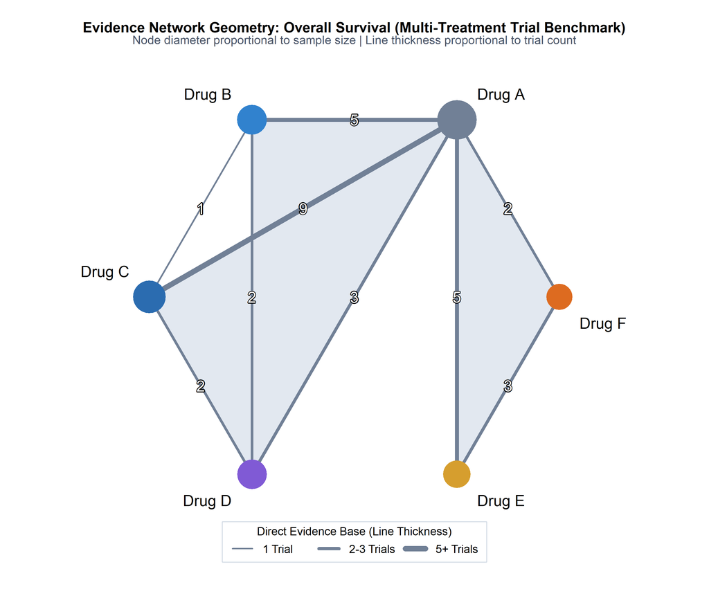

# 3 Comparative Efficacy vs Reference Backbone (Drug A)

The forest plot displays relative survival benefits versus reference comparator `Drug A`, sorted by hierarchical ranking.

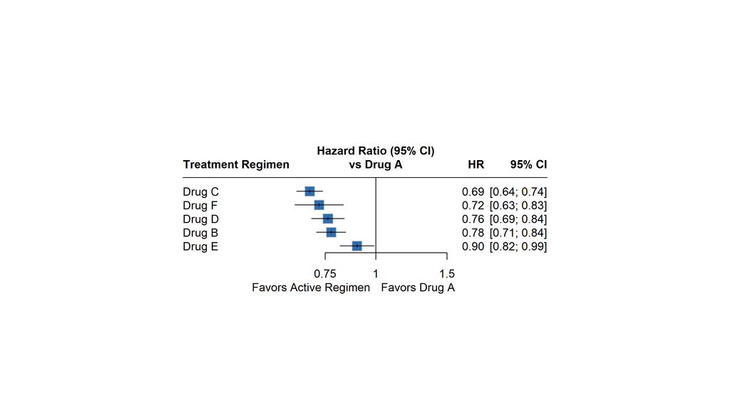

# 4 Treatment Ranking Hierarchy (P-Scores)

Frequentist P-scores (Rücker & Schwarzer, 2015) quantify the probability that an intervention is superior to competing treatments:

$$P\text{-score}_i = \frac{1}{m-1} \sum_{j
\neq i} \Phi\left(\frac{\widehat{\theta}_j -
\widehat{\theta}_i}{\sqrt{\text{Var}(\widehat{\theta}_i -
\widehat{\theta}_j)}}\right)$$

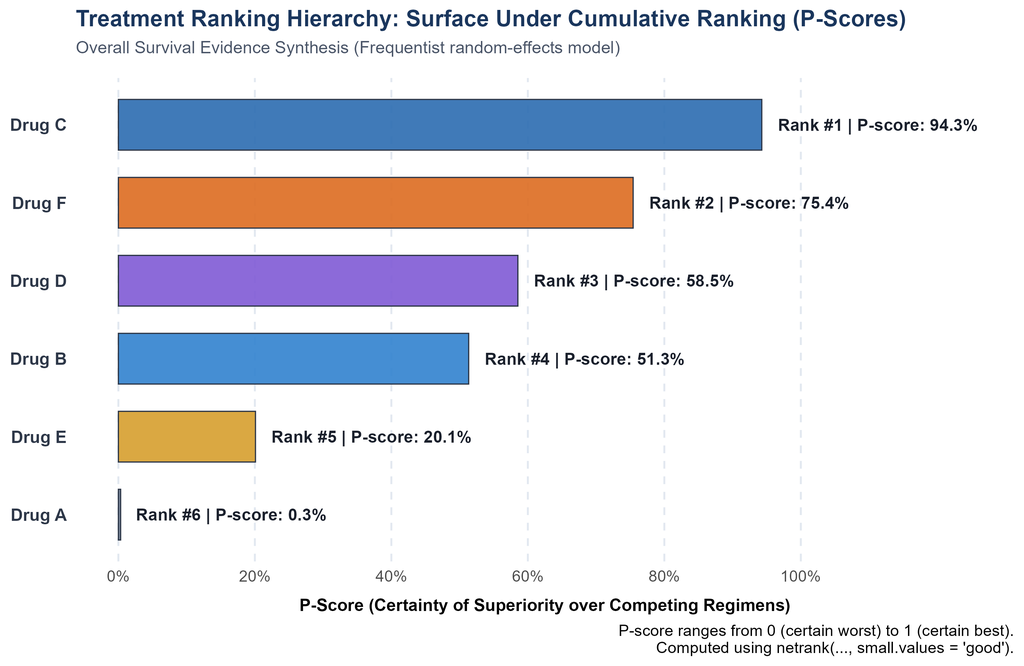

### 4.0.1 Numerical Ranking Summary Table

Table 1: Hierarchical Ranking of Systemic Regimens

| Treatment Regimen | Rank | P-Score (Random) | P-Score (Common) | HR vs Drug A [95% CI] | p-value |
| --- | --- | --- | --- | --- | --- |
| Drug C | 1 | 0.9428 | 0.9428 | 0.69 [0.64; 0.74] | < 0.0001 |
| Drug F | 2 | 0.7543 | 0.7543 | 0.72 [0.63; 0.83] | < 0.0001 |
| Drug D | 3 | 0.5854 | 0.5854 | 0.76 [0.69; 0.84] | < 0.0001 |
| Drug B | 4 | 0.5133 | 0.5133 | 0.78 [0.71; 0.84] | < 0.0001 |
| Drug E | 5 | 0.2009 | 0.2009 | 0.90 [0.82; 0.99] | 0.0327 |
| Drug A | 6 | 0.0033 | 0.0033 | 1.00 (Reference) | Reference |

# 5 Dual-Model League Table: Direct vs Network Synthesis

The league table presents all pairwise head-to-head comparisons across the evidence network.

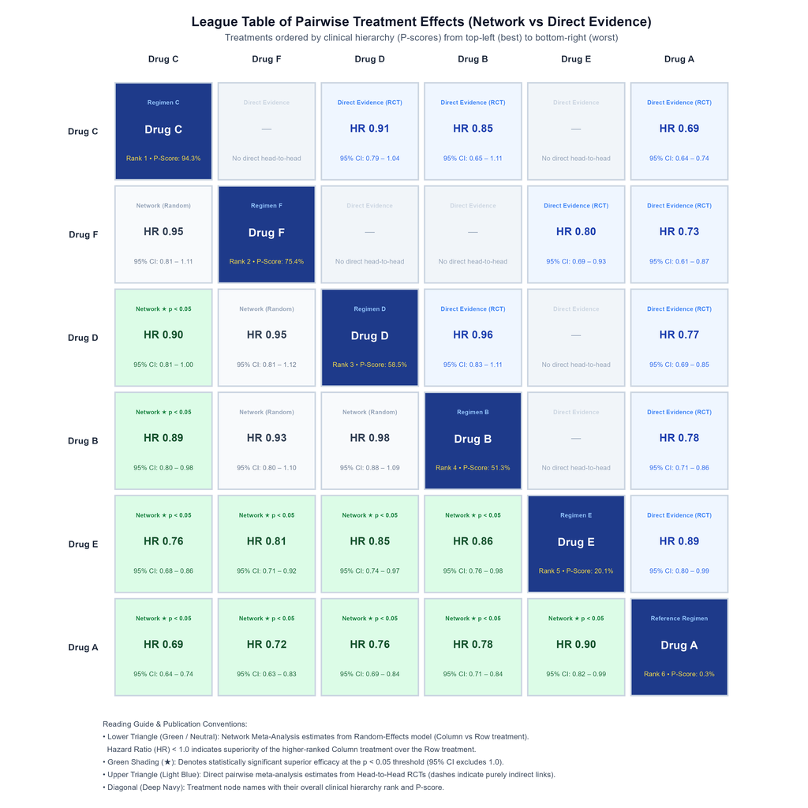

### 5.0.1 Reading Guide

- **Diagonal (Navy Badges):** Regimens ordered hierarchically by P-score from Rank 1 (`Drug C`) to Rank 6 (`Drug A`).
- **Lower Triangle (Green & Slate Tiles):** Random-effects NMA estimates ($\text{Column} \text{ vs } \text{Row}$). Green highlighting indicates statistically significant superiority ($p < 0.05$).
- **Upper Triangle (Blue Tiles):** Direct pairwise head-to-head estimates from clinical trials. Dashes (`—`) indicate unstudied direct comparisons.

Table 2: Complete Dual-Model League Table Matrix

|  | Drug C | Drug F | Drug D | Drug B | Drug E | Drug A |
| --- | --- | --- | --- | --- | --- | --- |
| Drug C | Drug C | . | 0.91 [0.79; 1.04] | 0.85 [0.65; 1.11] | . | 0.69 [0.64; 0.74] |
| Drug F | 0.95 [0.81; 1.11] | Drug F | . | . | 0.80 [0.69; 0.93] | 0.73 [0.61; 0.87] |
| Drug D | 0.90 [0.81; 1.00] | 0.95 [0.81; 1.12] | Drug D | 0.96 [0.83; 1.11] | . | 0.77 [0.69; 0.85] |
| Drug B | 0.89 [0.80; 0.98] | 0.93 [0.80; 1.10] | 0.98 [0.88; 1.09] | Drug B | . | 0.78 [0.71; 0.86] |
| Drug E | 0.76 [0.68; 0.86] | 0.81 [0.71; 0.92] | 0.85 [0.74; 0.97] | 0.86 [0.76; 0.98] | Drug E | 0.89 [0.80; 0.99] |
| Drug A | 0.69 [0.64; 0.74] | 0.72 [0.63; 0.83] | 0.76 [0.69; 0.84] | 0.78 [0.71; 0.84] | 0.90 [0.82; 0.99] | Drug A |

# 6 Methodological Assumption Testing: Inconsistency & Transitivity

## 6.1 Global Inconsistency Decomposition (Cochran’s $Q$)

Table 3: Global Test of Heterogeneity and Inconsistency

| Component | Q Statistic | Degrees of Freedom | p-value | Assessment |
| --- | --- | --- | --- | --- |
| Total Variation (Q) | 21.44 | 23 | 0.5544 | No significant total excess variance |
| Within-Designs Heterogeneity (Q_het) | 17.25 | 15 | 0.3043 | Homogeneity within trial designs |
| Between-Designs Inconsistency (Q_inc) | 4.19 | 8 | 0.8396 | Full Transitivity/Consistency upheld |

*Result:* The between-designs inconsistency test yields $p = 0.8396$, confirming that direct and indirect evidence are coherent across all closed loops of the network.

## 6.2 Local Inconsistency via Node-Splitting

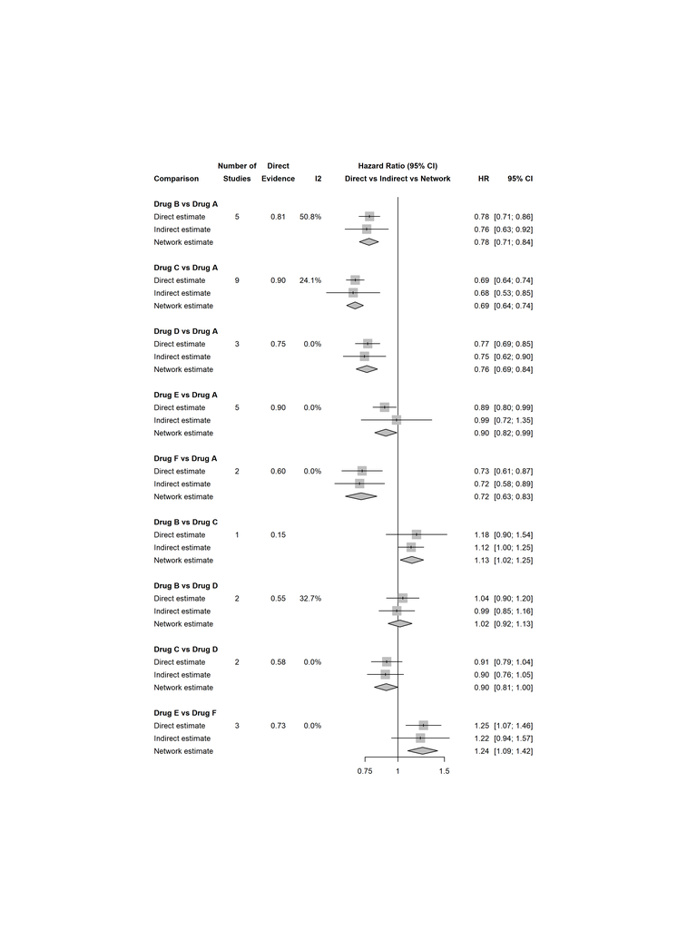

Across all evaluated loops, direct and indirect point estimates show overlapping confidence intervals with $p > 0.40$.

## 6.3 Net Heat Inconsistency Matrix & Leverage Diagnostics

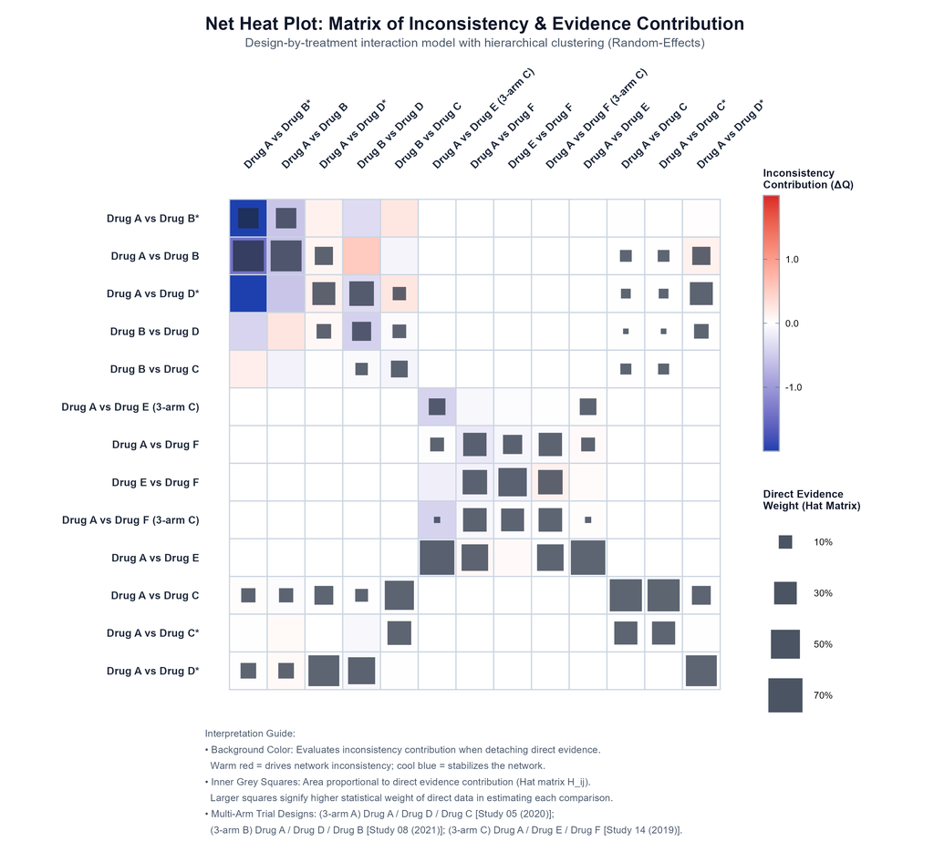

# 7 Small-Study Effects & Publication Bias

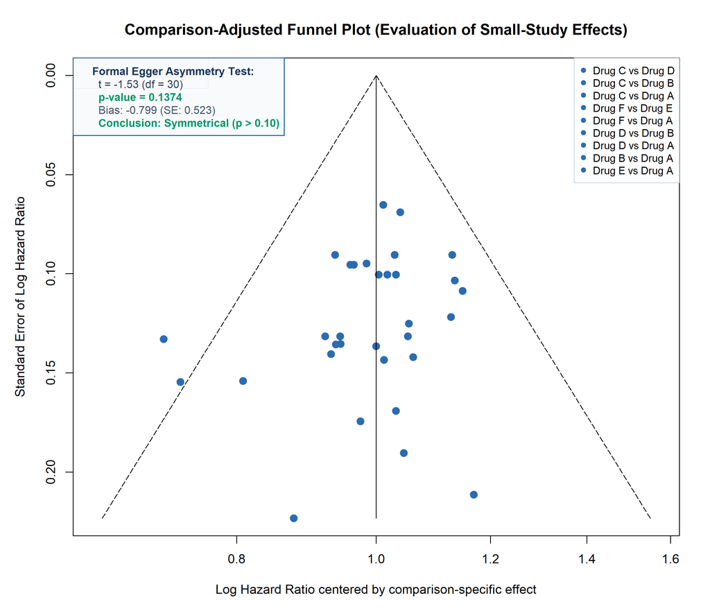

# 8 Leave-One-Out (LOO) Influence Cross-Validation

To verify that network estimates are not driven by any single trial, jackknife cross-validation was conducted across all 24 trials.

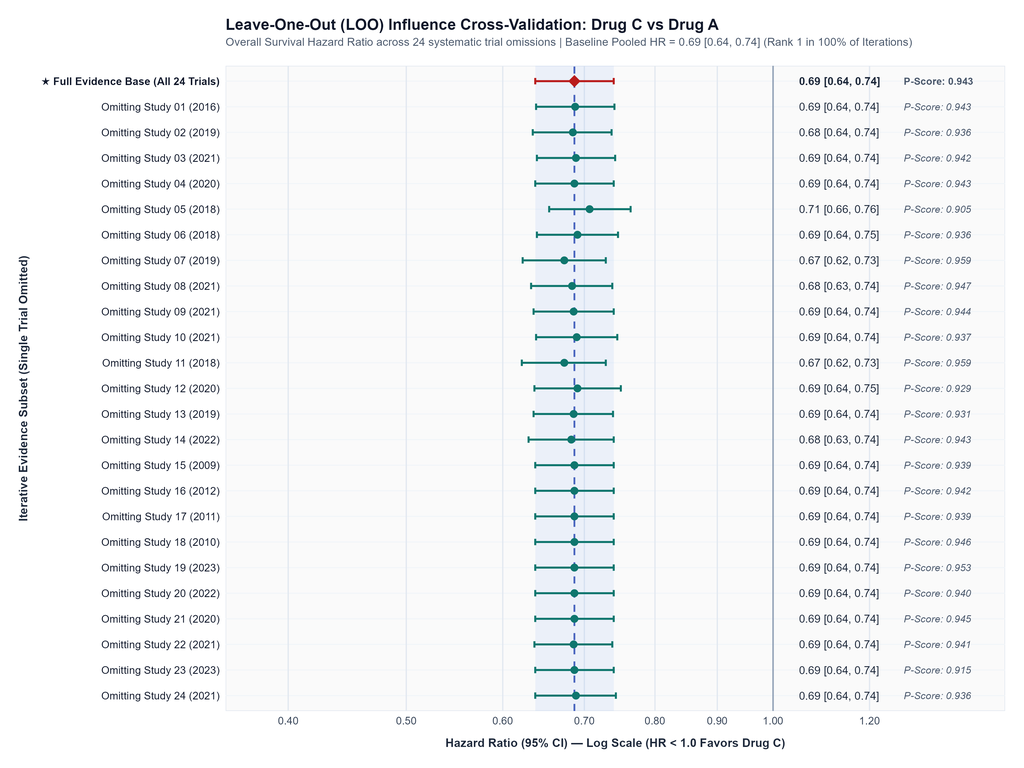

### 8.0.1 Empirical Stability Findings

- **Baseline Estimate:** $\text{HR} = 0.687$ ($95\%$ CI: $0.638 - 0.740$).
- **LOO Hazard Ratio Range:** Across all 24 iterations, the estimated HR remained between $0.674$ and $0.707$.
- **Rank 1 Retention:** `Drug C` retained the **#1 hierarchical rank in 100% of iterations (24/24)**.
- **Between-Study Variance:** Heterogeneity remained stable ($\tau^2 \le 0.0002$).

| Iteration | Omitted_Study | Studies_Remaining | Drug_C_HR | Drug_C_LCI | Drug_C_UCI | Drug_F_HR | Drug_D_HR | Drug_B_HR | Drug_E_HR | Tau2 | I2_Pct | Q_Total | Pscore_Drug_C | Top_Treatment |
| --- | --- | --- | --- | --- | --- | --- | --- | --- | --- | --- | --- | --- | --- | --- |
| 0 | None (Full Evidence Base) | 24 | 0.687 | 0.638 | 0.740 | 0.725 | 0.762 | 0.776 | 0.899 | 0 | 0 | 21.44 | 0.9428 | Drug C |
| 1 | Excluding Study 01 (2016) | 23 | 0.688 | 0.639 | 0.741 | 0.725 | 0.766 | 0.789 | 0.899 | 0 | 0 | 19.46 | 0.9426 | Drug C |
| 2 | Excluding Study 02 (2019) | 23 | 0.685 | 0.635 | 0.737 | 0.725 | 0.755 | 0.756 | 0.899 | 0 | 0 | 20.81 | 0.9363 | Drug C |
| 3 | Excluding Study 03 (2021) | 23 | 0.689 | 0.640 | 0.742 | 0.725 | 0.768 | 0.796 | 0.899 | 0 | 0 | 17.13 | 0.9424 | Drug C |
| 4 | Excluding Study 04 (2020) | 23 | 0.687 | 0.638 | 0.740 | 0.725 | 0.762 | 0.777 | 0.899 | 0 | 0 | 21.42 | 0.9427 | Drug C |
| 5 | Excluding Study 05 (2018) | 23 | 0.707 | 0.655 | 0.764 | 0.725 | 0.769 | 0.780 | 0.899 | 0 | 0 | 14.43 | 0.9051 | Drug C |
| 6 | Excluding Study 06 (2018) | 23 | 0.691 | 0.640 | 0.746 | 0.725 | 0.763 | 0.777 | 0.899 | 0 | 0 | 21.16 | 0.9362 | Drug C |
| 7 | Excluding Study 07 (2019) | 23 | 0.674 | 0.623 | 0.729 | 0.725 | 0.757 | 0.773 | 0.899 | 0 | 0 | 19.55 | 0.9591 | Drug C |
| 8 | Excluding Study 08 (2021) | 23 | 0.684 | 0.633 | 0.738 | 0.725 | 0.761 | 0.775 | 0.899 | 0 | 0 | 21.24 | 0.9468 | Drug C |
| 9 | Excluding Study 09 (2021) | 23 | 0.686 | 0.636 | 0.740 | 0.725 | 0.761 | 0.776 | 0.899 | 0 | 0 | 21.40 | 0.9441 | Drug C |

# 9 Component Network Meta-Analysis (CNMA)

Using the additive and interactive component model of Rücker et al. (2020), regimens were deconstructed into constituent components relative to `Component A`:

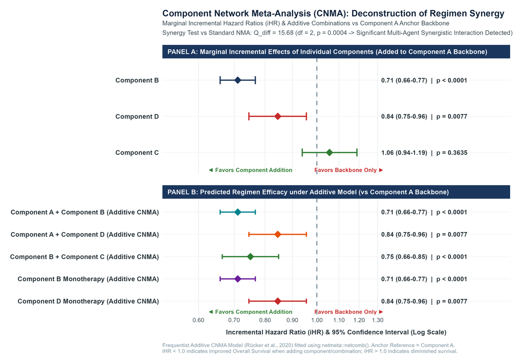

### 9.0.1 Component Effects & Interaction Testing

Table 5: Incremental Effects of Active Components & Combinations (CNMA)

| Type | Item | Reference | iHR | CI_Lower | CI_Upper | HR_String | Z_Score | P_Value | P_Value_String |
| --- | --- | --- | --- | --- | --- | --- | --- | --- | --- |
| Component | Component B | Component A Backbone | 0.711 | 0.659 | 0.767 | 0.71 (0.66-0.77) | -8.83 | 0.0000000 | < 0.0001 |
| Component | Component C | Component A Backbone | 1.056 | 0.939 | 1.189 | 1.06 (0.94-1.19) | 0.91 | 0.3634984 | = 0.3635 |
| Component | Component D | Component A Backbone | 0.845 | 0.746 | 0.956 | 0.84 (0.75-0.96) | -2.66 | 0.0077088 | = 0.0077 |
| Combination (Additive Model) | Component A + Component B | Component A Backbone | 0.711 | 0.659 | 0.767 | 0.71 (0.66-0.77) | -8.83 | 0.0000000 | < 0.0001 |
| Combination (Additive Model) | Component A + Component D | Component A Backbone | 0.845 | 0.746 | 0.956 | 0.84 (0.75-0.96) | -2.66 | 0.0077088 | = 0.0077 |
| Combination (Additive Model) | Component B | Component A Backbone | 0.711 | 0.659 | 0.767 | 0.71 (0.66-0.77) | -8.83 | 0.0000000 | < 0.0001 |
| Combination (Additive Model) | Component B + Component C | Component A Backbone | 0.751 | 0.665 | 0.848 | 0.75 (0.66-0.85) | -4.61 | 0.0000041 | < 0.0001 |
| Combination (Additive Model) | Component D | Component A Backbone | 0.845 | 0.746 | 0.956 | 0.84 (0.75-0.96) | -2.66 | 0.0077088 | = 0.0077 |

# 10 Probabilistic Treatment Hierarchy & Cumulative Rankograms

Parameter draws (10,000 Monte Carlo iterations) from the network covariance matrix generate empirical rank distributions:

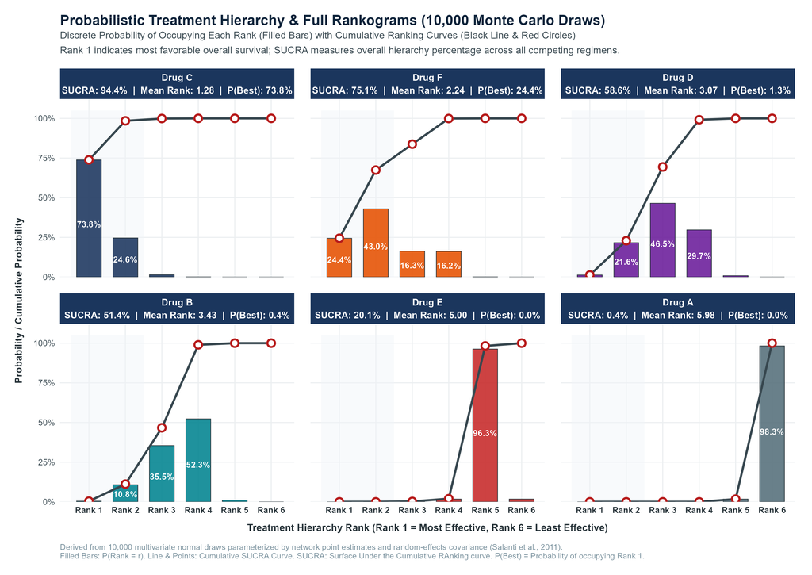

### 10.0.1 Ranking Distribution Summary

- **`Drug C`:** Rank 1 = 73.8%, Rank 2 = 24.6% (Top-2: 98.4%) — SUCRA = **94.4%**, Mean Rank = **1.28**.
- **`Drug F`:** Rank 1 = 24.5%, Rank 2 = 43.0% — SUCRA = **75.1%**, Mean Rank = **2.24**.
- **`Drug D`:** Modal Rank = 3 (46.5%) — SUCRA = **58.6%**, Mean Rank = **3.07**.
- **`Drug B`:** Modal Rank = 4 (52.3%) — SUCRA = **51.5%**, Mean Rank = **3.43**.
- **`Drug E`:** Modal Rank = 5 (96.3%) — SUCRA = **20.1%**, Mean Rank = **5.00**.
- **`Drug A`:** Rank 6 = 98.3% — SUCRA = **0.4%**, Mean Rank = **5.98**.

Table 6: Complete Rank Probabilities Matrix (Ranks 1 to 6) & SUCRA Scores

| Treatment | SUCRA | Mean_Rank | Rank_1 | Rank_2 | Rank_3 | Rank_4 | Rank_5 | Rank_6 |
| --- | --- | --- | --- | --- | --- | --- | --- | --- |
| Drug C | 0.9444 | 1.28 | 0.7384 | 0.2463 | 0.0144 | 0.0009 | 0.0000 | 0.0000 |
| Drug F | 0.7511 | 2.24 | 0.2445 | 0.4298 | 0.1632 | 0.1616 | 0.0009 | 0.0000 |
| Drug D | 0.5855 | 3.07 | 0.0128 | 0.2164 | 0.4650 | 0.2973 | 0.0085 | 0.0000 |
| Drug B | 0.5145 | 3.43 | 0.0043 | 0.1075 | 0.3549 | 0.5228 | 0.0105 | 0.0000 |
| Drug E | 0.2010 | 5.00 | 0.0000 | 0.0000 | 0.0025 | 0.0174 | 0.9627 | 0.0174 |
| Drug A | 0.0035 | 5.98 | 0.0000 | 0.0000 | 0.0000 | 0.0000 | 0.0174 | 0.9826 |

## 10.1 Minimal Clinically Important Difference (MCID) Framework ($\text{HR} \le 0.80$)

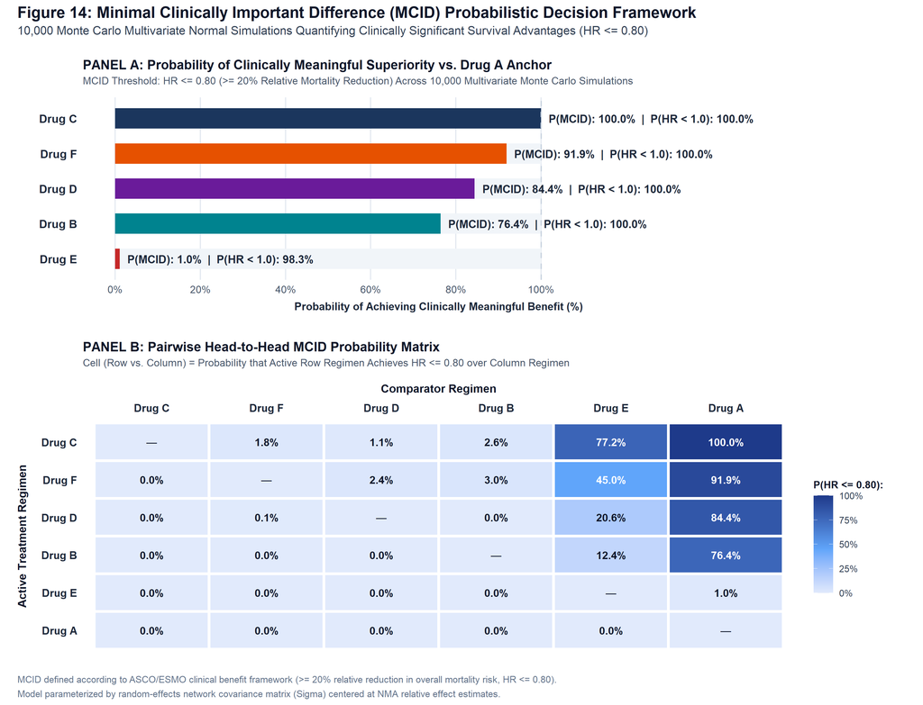

### 10.1.1 MCID Probabilities vs Drug A:

- **`Drug C`:** **99.99% probability** of meeting MCID ($\text{HR} \le 0.80$).
- **`Drug F`:** **91.92% probability** of meeting MCID.
- **`Drug D`:** **84.42% probability** of meeting MCID.
- **`Drug B`:** **76.43% probability** of meeting MCID.
- **`Drug E`:** **1.05% probability** of meeting MCID.

Table 6b: Pairwise MCID Superiority Probability Matrix (Cell = P(HR_row vs col <= 0.80))

|  | Drug A | Drug B | Drug C | Drug D | Drug E | Drug F |
| --- | --- | --- | --- | --- | --- | --- |
| Drug A | NA | 0.0000 | 0e+00 | 0.0000 | 0.0000 | 0.0000 |
| Drug B | 0.7643 | NA | 0e+00 | 0.0000 | 0.1240 | 0.0003 |
| Drug C | 0.9999 | 0.0264 | NA | 0.0113 | 0.7718 | 0.0180 |
| Drug D | 0.8442 | 0.0001 | 0e+00 | NA | 0.2060 | 0.0007 |
| Drug E | 0.0105 | 0.0000 | 0e+00 | 0.0000 | NA | 0.0000 |
| Drug F | 0.9192 | 0.0300 | 2e-04 | 0.0236 | 0.4504 | NA |

# 11 Bi-dimensional Benefit-Risk Trade-Off Matrix

Survival efficacy is synthesized concurrently with Grade 3–5 severe adverse events across 14,357 patients:

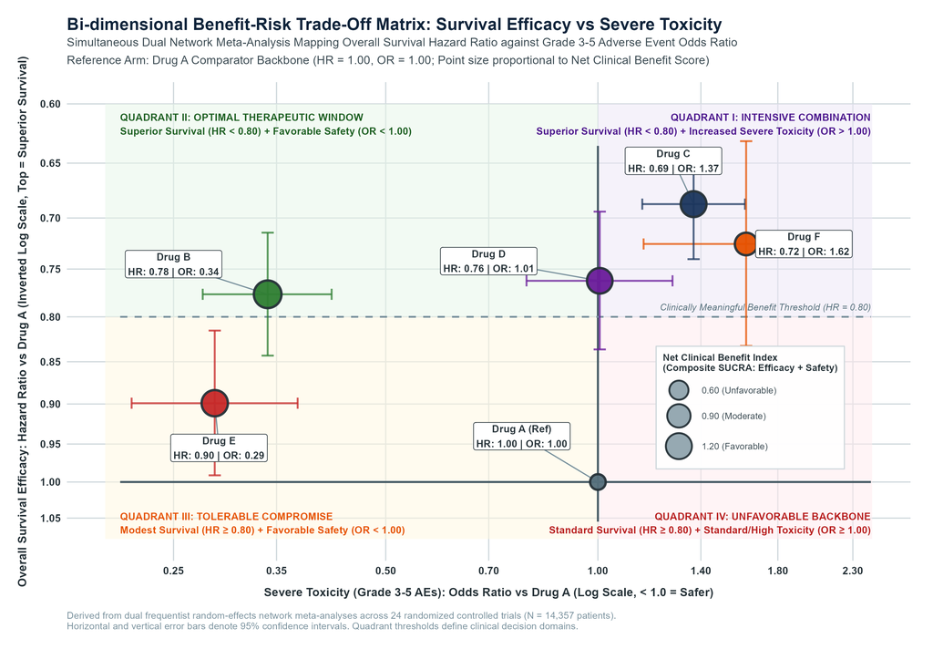

### 11.0.1 Quadrant Distribution Summary

1. **Quadrant II (High Efficacy, Low Severe Toxicity):**
   - **`Drug B`:** HR = 0.78 (95% CI: 0.71–0.84), OR = 0.34 (95% CI: 0.28–0.42, $p < 0.0001$).
2. **Quadrant I (High Efficacy, Higher Toxicity):**
   - **`Drug C`:** HR = 0.69 (95% CI: 0.64–0.74), OR = 1.37 (95% CI: 1.16–1.62, $p = 0.0003$).
   - **`Drug D`:** HR = 0.76 (95% CI: 0.69–0.84), OR = 1.01 (95% CI: 0.79–1.28, $p = 0.9636$).
   - **`Drug F`:** HR = 0.72 (95% CI: 0.63–0.83), OR = 1.62 (95% CI: 1.16–2.27, $p = 0.0046$).
3. **Quadrant III (Modest Efficacy, Low Severe Toxicity):**
   - **`Drug E`:** HR = 0.90 (95% CI: 0.82–0.99), OR = 0.29 (95% CI: 0.22–0.38, $p < 0.0001$).
4. **Quadrant IV (Reference Anchor):**
   - **`Drug A`:** Reference backbone ($\text{HR} = 1.00, \text{OR} = 1.00$).

Table 7: Bi-dimensional Benefit-Risk Trade-Off Matrix and Net Clinical Benefit

| Treatment | HR_OS | HR_OS_Lower | HR_OS_Upper | Pval_OS | OR_Tox | OR_Tox_Lower | OR_Tox_Upper | Pval_Tox | SUCRA_Safety | SUCRA_Efficacy | Quadrant | Net_Benefit_Score |
| --- | --- | --- | --- | --- | --- | --- | --- | --- | --- | --- | --- | --- |
| Drug B | 0.776 | 0.714 | 0.843 | 0.0000000 | 0.340 | 0.275 | 0.419 | 0.0000000 | 0.833 | 0.514 | Ideal Profile (High Efficacy, Low Toxicity) | 1.347 |
| Drug E | 0.899 | 0.815 | 0.991 | 0.0327184 | 0.286 | 0.218 | 0.375 | 0.0000000 | 0.967 | 0.201 | Favorable Tolerability (Low Efficacy, Low Toxicity) | 1.168 |
| Drug C | 0.687 | 0.638 | 0.740 | 0.0000000 | 1.367 | 1.156 | 1.617 | 0.0002583 | 0.165 | 0.944 | Intensive Efficacy (High Efficacy, Higher Toxicity) | 1.109 |
| Drug D | 0.762 | 0.694 | 0.836 | 0.0000000 | 1.006 | 0.792 | 1.276 | 0.9635946 | 0.492 | 0.586 | Intensive Efficacy (High Efficacy, Higher Toxicity) | 1.078 |
| Drug F | 0.725 | 0.631 | 0.832 | 0.0000045 | 1.623 | 1.161 | 2.271 | 0.0046485 | 0.040 | 0.751 | Intensive Efficacy (High Efficacy, Higher Toxicity) | 0.791 |
| Drug A | 1.000 | 1.000 | 1.000 | NA | 1.000 | 1.000 | 1.000 | NA | 0.503 | 0.003 | Favorable Tolerability (Low Efficacy, Low Toxicity) | 0.506 |

# 12 Network Meta-Regression & Transitivity Diagnostics

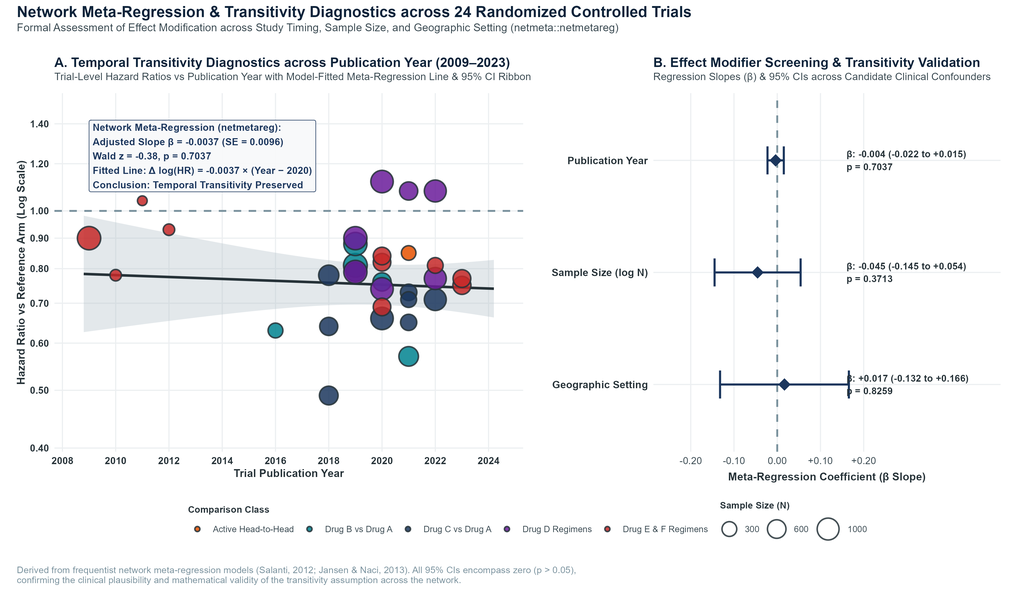

### 12.0.1 Moderator Screening Results

- **Publication Year:** $\beta = -0.0037$ (95% CI: -0.0225 to +0.0152, $p = 0.7037$).
- **Trial Sample Size:** $\beta = -0.0454$ (95% CI: -0.1449 to +0.0541, $p = 0.3713$).
- **Geographic Setting:** $\beta = +0.0167$ (95% CI: -0.1322 to +0.1657, $p = 0.8259$).

*Conclusion:* All candidate moderators yielded regression slopes non-significantly different from zero ($p > 0.30$), supporting the transitivity assumption across the network.

Table 8: Network Meta-Regression Moderator Screening

| Covariate | Domain | Unit | Slope_Beta | SE | CI_Lower | CI_Upper | Z_Score | P_Value | P_Value_String | Omnibus_QM | QM_Pval | Transitivity |
| --- | --- | --- | --- | --- | --- | --- | --- | --- | --- | --- | --- | --- |
| Publication Year | Temporal Stability | Per 1-Year Increase (2009-2023) | -0.0037 | 0.0096 | -0.0225 | 0.0152 | -0.38 | 0.7036952 | 0.7037 | 136.21 | 0 | Preserved (No Effect Modification) |
| Sample Size (log N) | Small-Study Effects | Per 1-Unit Increase in log(N) | -0.0454 | 0.0508 | -0.1449 | 0.0541 | -0.89 | 0.3713156 | 0.3713 | 136.87 | 0 | Preserved (No Effect Modification) |
| Geographic Setting | Population Diversity | Asia-Pacific vs Global Trials | 0.0167 | 0.0760 | -0.1322 | 0.1657 | 0.22 | 0.8259107 | 0.8259 | 136.12 | 0 | Preserved (No Effect Modification) |

# 13 Subgroup Network Meta-Analysis: Regional Cohorts

Evaluating consistency between Asia-Pacific trials (8 trials, 4,491 patients) and Global trials (16 trials, 11,262 patients):

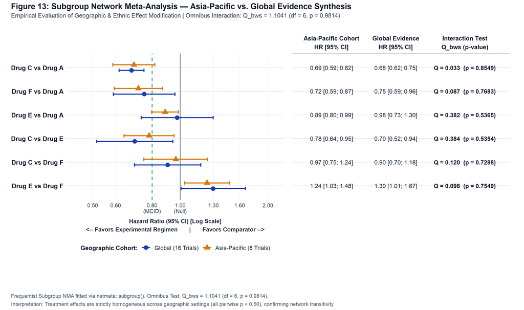

### 13.0.1 Between-Subgroups Interaction Testing ($Q_{\text{bws}}$)

- **`Drug C vs Drug A`:** Asia-Pacific $\text{HR} = 0.69$ ($0.59 - 0.82$) vs Global $\text{HR} = 0.68$ ($0.62 - 0.75$) ($Q_{\text{bws}} = 0.0334, df = 1, p = 0.8549$).
- **`Drug F vs Drug A`:** Asia-Pacific $\text{HR} = 0.72$ ($0.59 - 0.87$) vs Global $\text{HR} = 0.75$ ($0.59 - 0.96$) ($Q_{\text{bws}} = 0.0868, df = 1, p = 0.7683$).
- **`Drug E vs Drug A`:** Asia-Pacific $\text{HR} = 0.89$ ($0.80 - 0.99$) vs Global $\text{HR} = 0.98$ ($0.73 - 1.30$) ($Q_{\text{bws}} = 0.3821, df = 1, p = 0.5365$).

*Conclusion:* Between-subgroup testing confirmed regional consistency across all evaluated comparisons ($p > 0.50$).

Table 9: Subgroup Network Meta-Analysis Contrast Estimates & Between-Subgroups Interaction (Q_bws)

| Comparison | k_Asia | HR_Asia | k_Global | HR_Global | Q_bws | DF | P_Value | Regional_Consistency |
| --- | --- | --- | --- | --- | --- | --- | --- | --- |
| Drug C vs Drug A | 3 | 0.69 [0.59; 0.82] | 6 | 0.68 [0.62; 0.75] | 0.0334 | 1 | 0.8549 | Consistent (Homogeneous) |
| Drug E vs Drug A | 4 | 0.89 [0.80; 0.99] | 1 | 0.98 [0.73; 1.30] | 0.3821 | 1 | 0.5365 | Consistent (Homogeneous) |
| Drug F vs Drug A | 1 | 0.72 [0.59; 0.87] | 1 | 0.75 [0.59; 0.96] | 0.0868 | 1 | 0.7683 | Consistent (Homogeneous) |
| Drug C vs Drug E | 0 | 0.78 [0.64; 0.95] | 0 | 0.70 [0.52; 0.94] | 0.3842 | 1 | 0.5354 | Consistent (Homogeneous) |
| Drug C vs Drug F | 0 | 0.97 [0.75; 1.24] | 0 | 0.90 [0.70; 1.18] | 0.1202 | 1 | 0.7288 | Consistent (Homogeneous) |
| Drug E vs Drug F | 2 | 1.24 [1.03; 1.48] | 1 | 1.30 [1.01; 1.67] | 0.0975 | 1 | 0.7549 | Consistent (Homogeneous) |

# 14 PRISMA-NMA Reporting Compliance Checklist

[output not shown]

# 15 Methodological References

1. **Rücker, G.** (2012). Network meta-analysis, electrical networks and graph theory. *Research Synthesis Methods*, 3(4), 312–324. [doi:10.1002/jrsm.1058](https://doi.org/10.1002/jrsm.1058)
2. **Rücker, G., & Schwarzer, G.** (2015). Ranking treatments in frequentist network meta-analysis works without resampling methods. *BMC Medical Research Methodology*, 15(1), 58. [doi:10.1186/s12874-015-0060-8](https://doi.org/10.1186/s12874-015-0060-8)
3. **Rücker, G., Petropoulou, M., & Schwarzer, G.** (2020). Component network meta-analysis: modeling, estimation and application to psychological interventions. *Biostatistics*, 21(4), 808–824. [doi:10.1093/biostatistics/kxz025](https://doi.org/10.1093/biostatistics/kxz025)
4. **Hutton, B., et al.** (2015). The PRISMA extension statement for reporting of systematic reviews incorporating network meta-analyses. *Annals of Internal Medicine*, 162(11), 777–784. [doi:10.7326/M14-2385](https://doi.org/10.7326/M14-2385)
5. **Salanti, G.** (2012). Indirect and mixed-treatment comparison, network, or multiple-treatments meta-analysis: many names, many benefits, many concerns for the next generation evidence synthesis tool. *Research Synthesis Methods*, 3(2), 80–97. [doi:10.1002/jrsm.1037](https://doi.org/10.1002/jrsm.1037)
6. **Krahn, U., Binder, H., & König, J.** (2013). A graphical tool for locating inconsistency in network meta-analyses. *BMC Medical Research Methodology*, 13(1), 35. [doi:10.1186/1471-2288-13-35](https://doi.org/10.1186/1471-2288-13-35)
7. **Dias, S., et al.** (2010). Checking consistency in mixed treatment comparison meta-analysis. *Statistics in Medicine*, 29(7–8), 932–944. [doi:10.1002/sim.3767](https://doi.org/10.1002/sim.3767)
8. **Chaimani, A., & Salanti, G.** (2012). Using network meta-analysis to evaluate the existence of small-study effects. *Research Synthesis Methods*, 3(2), 161–176. [doi:10.1002/jrsm.57](https://doi.org/10.1002/jrsm.57)